# introduction (week 1+)

03 September 2019

## Introduction

## Administrative trivia

- Instructors: Dr. Benjamin Bolker and Dr. Weijie Pang
- TAs: Nik Počuča, Steve Cygu, Aghigh Farhadi (marking)
- course web page: http://bbolker.github.io/math1mp
- course outline: http://bbolker.github.io/math1mp/admin/outline.html
- Grading
  - Assignments (10%)
  - Quizzes (5%)
  - Final project (5%)
  - Midterm tests (2 \(\times\) 20%)
  - Final exam (40%)
- homework assignment announcements policy  
  (web page, Avenue: **not** in class)
- Laptop policy
- Course material on web page and Avenue to Learn
- Expectations of professor and students
- Textbook (optional); Gries et al. *Practical Programming* 3d ed. (see outline)
- also see [resources](https://github.com/bbolker/math1mp/misc/resources.md)

## Course content

reasonable balance among

- nitty-gritty practical programming instruction:

  > … I just sat down in front of a text editor, with nothing but thoughts, and ended up with a program that did exactly what I wanted it to a few hours later … ([ankit panda](https://web.archive.org/web/20160421222949/http://www.ankitpanda.com/pythonicity/))
- conceptual foundations of computing/computer science
- context/culture of mathematical/scientific computing
- interesting applications

## Installing Python

- CodeLab: http://www.turingscraft.com/go.html
- [PythonAnywhere](https://www.pythonanywhere.com/)
- Everyone must have access to a computer with Python3 installed.
  - See installation instructions

## Overview of math/sci computing

## Using computers in math and science

- math users vs. understanders vs. developers
- develop conjectures; draw pictures; write manuscripts
- mathematical proof (e.g. [four-colo(u)r theorem](http://en.wikipedia.org/wiki/Four_color_theorem) and [other examples](http://math.stackexchange.com/questions/1084230/what-are-some-theorems-that-currently-only-have-computer-assisted-proofs)); computer algebra
- applied math: cryptography, tomography, logistics, finance, fluid dynamics, …
- applied statistics: bioinformatics, Big Data/analytics, …
- discrete vs. continuous math

## Running Python

## Fun!

[**Hello, world**](https://en.wikipedia.org/wiki/%22Hello,_World!%22_program) (always the first program you write in a new computer language)

```python
print('hello, python world!')
```

```
## hello, python world!
```

Python as a fancy calculator:

```python
print(62**2*27/5+3)
```

```
## 20760.6
```

*reference*: [Python intro section 3.1.1](https://docs.python.org/3/tutorial/introduction.html)

## Interlude: about Python

- [programming languages](http://crashworks.org/if_programming_languages_were_vehicles/)
  - Python: [scripting](http://en.wikipedia.org/wiki/Scripting_language); high-level; glue; general-purpose; flexible
  - contrast: *domain-specific* scripting languages (MATLAB, R, Mathematica, Maple)
  - contrast: *general-purpose* scripting languages (Perl, PHP)
  - contrast: general-purpose *compiled* languages (Java, C, C++) ("close to the metal")
- relatively modern (1990s; Python 3, 2008)
- currently the [5th most popular computer language](http://www.tiobe.com/index.php/content/paperinfo/tpci/index.html) overall (up from 8th in 2015); [most popular for teaching](http://cacm.acm.org/blogs/blog-cacm/176450-python-is-now-the-most-popular-introductory-teaching-language-at-top-us-universities/fulltext)
- well suited to mathematical/scientific/technical ([NumPy](http://www.numpy.org); [SciPy](http://www.scipy.org); [Python in Finance](https://www.safaribooksonline.com/library/view/python-for-finance/9781491945360/ch01.html))
- ex.: [Sage](http://www.sagemath.org); [BioPython](http://www.biopython.org)

## the "prime walk" (from [math.stackexchange.ca](http://tinyurl.com/primewalk))

1. start at the origin, heading right, counting up from 1
2. move forward one space, counting up, until you find a prime
3. turn 90\({}^\circ\) clockwise
4. repeat steps 2 and 3 until you get bored

code here (`bbolker.github.io/math1mp/code/primewalk.py`)

**Note**:

- easier to understand/modify than write from scratch
- build on existing components (*modules*)

## Interfaces

- integrated development environment (IDE), command line/console (Spyder)
- programming editor
- notebooks
- **not** MS Word!

## Features

- syntax highlighting, bracket-matching, hot-pasting
- integrated help
- integrated debugging tools
- integrated project management tools
- **most important**: maintain reproducibility; well-defined **workflows**

## Assignment and types (PP \(\S2.4\))

- superficially simple
  - set aside *memory* space, create a symbol that *points to* that space
  - `=` is the **assignment operator** ("gets", not "equals")
  - `<variable> = <value>`
  - variable names
    - what is legal? (names include letters, numbers, underscores, must start with a letter)
    - what is customary? [convention](https://www.python.org/dev/peps/pep-0008/#id30) is `variables_like_this` ("snake case")
    - what works well? `v` vs. `temporary_variable_for_loop`
    - same principles apply to file, directory/folder names
- variables are of different [**types**](https://docs.python.org/3/library/stdtypes.html)
  - built-in: integer (`int`), floating-point (`float`), complex, **Boolean** (`bool`: `True` or `False`),
  - *dynamic* typing
    - Python usually "does what you mean", converts types when sensible
  - *strong* typing
    - try `print(type(x))` for different possibilities (`x=3`; `x=3.0`; `x="a"`)
    - *what happens if you try `x=a`?*
    - **don't be afraid to experiment!**

**Examples**

```python
x=3
y=3.0
z="a"
q=complex(1,2)
type(x+y)  ## mixed arithmetic
type(int(x+y))  ## int(), float() convert explicitly
type(x+z)
type(q)
type(x+q)
type(True)
type(True+1) ## WAT
```

Check out the [Python tutor](http://pythontutor.com/visualize.html#mode=edit) for these examples

## Arithmetic operators, precedence

- exponentiation (`**`)
- negation ("unary minus") (`-`)
- multiplication/division (`*`,`/`,`//`=integer division,`%`=remainder ("modulo"))
- addition/subtraction (`+`, `-` ("binary"))

Use parentheses when in doubt!

**Puzzle:** what is `-1**2`? Why?

## Logical operators (PP \(\S5.1\))

- comparison: (`==`, `!=`)
- inequalities: `>`, `<`, `>=`, `<=`,
- basic logic: (`and`, `or`, `not`)
- remember your truth tables, e.g. `not(a and b)` equals `(not a) or (not b)`

```python
a = True; b = False; c=1; d=0
a and b
not(a and not b)
a and not(b>c)
a==c  ## careful!
not(d)
not(c)
```

**operator precedence**

- remember [order of operations in arithmetic](http://xkcd.com/992/)
- `not` has higher precedence than `and`, `or`. When in doubt use parentheses …

From [CodingBat](http://codingbat.com/prob/p120546):

> We have two monkeys, a and b, and the parameters `a_smile` and `b_smile` indicate if each is smiling. We are in trouble if they are both smiling or if neither of them is smiling. Return `True` if we are in trouble.

```
monkey_trouble(True, True) → True
monkey_trouble(False, False) → True
monkey_trouble(True, False) → False
```

## Truth tables

| A | B | A and B | A or B | not A |
| --- | --- | --- | --- | --- |
| True | True | True | True | False |
| True | False | False | True | False |
| False | True | False | True | True |
| False | False | False | False | True |

## Logical expressions

- The logical expression: `not not a and not b or a` is equivalent to `((not (not a)) and (not b)) or a` since the operator `not` takes precedence over the operators `and` and `or`.
- So if `a = True` and `b = False` this evaluates to `True`
- Since `not not a` is equivalent to `a`, we can simplify the expression to just `(a and not b) or a`.
- Can we simplify this further?

What can we do with `not a and not b` ?

## More [CodingBat](http://codingbat.com) problems

- [squirrel_play](http://codingbat.com/prob/p135815)
- [cigar_party](http://codingbat.com/prob/p195669)

## String operations (PP chapter 4)

*reference*: [Python intro](https://docs.python.org/3/tutorial/introduction.html) section 3.1.2

- Less generally important, but fun
- `+` concatenates
- `*` replicates and concatenates
- `in` searches for a substring

```python
a = "xyz"
b = "abc"
a+1  ## error
a+b
b*3
(a+" ")*5
b in a
```

CodingBat problems:

- [make_abba](http://codingbat.com/prob/p182144)
- [make_tags](http://codingbat.com/prob/p132290)

One more useful string operation: `len(s)` returns the length (number of characters)

## Indexing and slicing

## Indexing

- Extracting elements is called **indexing** a list
- Indexing [starts from zero](http://xkcd.com/163/)
- Negative indices count backward from the end of the string  
  (-1 is the last element)
- Indexing a non-existent element gives an error

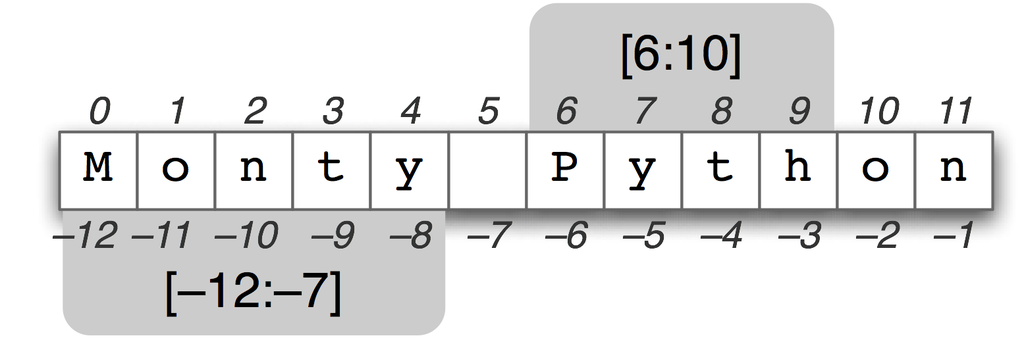

slicing

## Slicing

- Extracting (consecutive) sets of elements is called [**slicing**](http://stackoverflow.com/questions/509211/explain-pythons-slice-notation)
- Slicing non-existent element(s) gives a truncated result
- Slicing specifies *start*, *end*, *step* (or "stride")
- Leaving out a bit goes from the beginning/to the end
- Slicing works on strings too!

```python
x[:]        # everything
x[a:b]      # element a (zero-indexed) to b-1
x[a:]       # a to end
x[:b]       # beginning to b-1
x[a:b:n]    # from a to b-1 in steps of n
```

- generate a list of odd numbers from 3 to 15
- reverse a string?

## String slicing practice

From CodingBat:

- [first_two](http://codingbat.com/prob/p184816)
- [first_half](http://codingbat.com/prob/p107010)

## String methods: examples

Strings have lots of methods, for example:

```python
x = "abcdef"
x.upper()
```

```
## 'ABCDEF'
```

```python
x.capitalize()
```

```
## 'Abcdef'
```

```python
x.endswith("f")
```

```
## True
```

```python
x.startswith("qrs")
```

```
## False
```

```python
x.islower()
```

```
## True
```